# Social Power NBA Dataset - Final Report

Julia Wilkins & Adrian Naranjo

# Introduction

For our final project, we chose to use the Social Power NBA Dataset (https://www.kaggle.com/noahgift/social-power-nba) which contains performance, salary, Wikipedia pageviews, and Twitter retweet/favorite data for NBA players in the 2016-2017 season. We explored 3 questions using this data.

#### Can we predict…

1. Salary from performance statistics?
2. Points per game based on other performance metrics?
3. Salary based on social media stats?

We had limitations due to the small sample size ($n$) of the dataset. For the performance statistics, we had $n = 446$, which was relatively small when compared to the number of predictors, $p = 36$. Only $n = 237$ players had all available social media statistics ($p = 3$). In this report, the focus is primarily on question 1, while question 2 and 3 are more exploratory. The report begins with a exploratory data analysis of the data before diving into the questions, and then discussing conclusions and future work.

# Exploratory Data Analysis (EDA)

### Salary EDA: Distribution of Individual Salaries

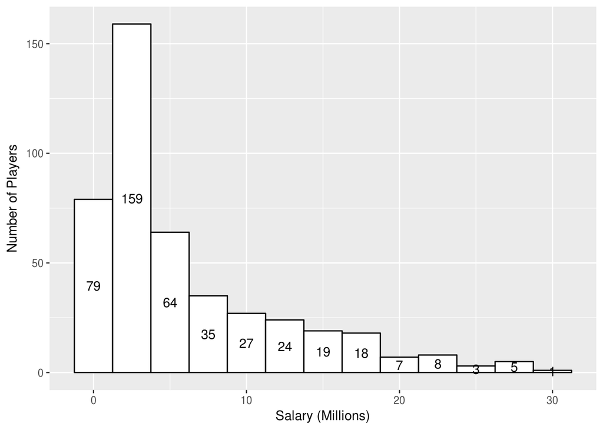

Note: bins are $2.5 mil

| Percentile | Salary |
| --- | --- |
| 0% | 31969 |
| 10% | 874636 |
| 20% | 1312611 |
| 30% | 1536288 |
| 40% | 2318280 |
| 50% | 3488000 |
| 60% | 5000000 |
| 70% | 7000000 |
| 80% | 11020000 |
| 90% | 15902211 |
| 100% | 30963450 |

### Salary EDA: Salary by Position and Median Salaries

A view of salary by position reveals centers have a slightly higher median salary than other positions.

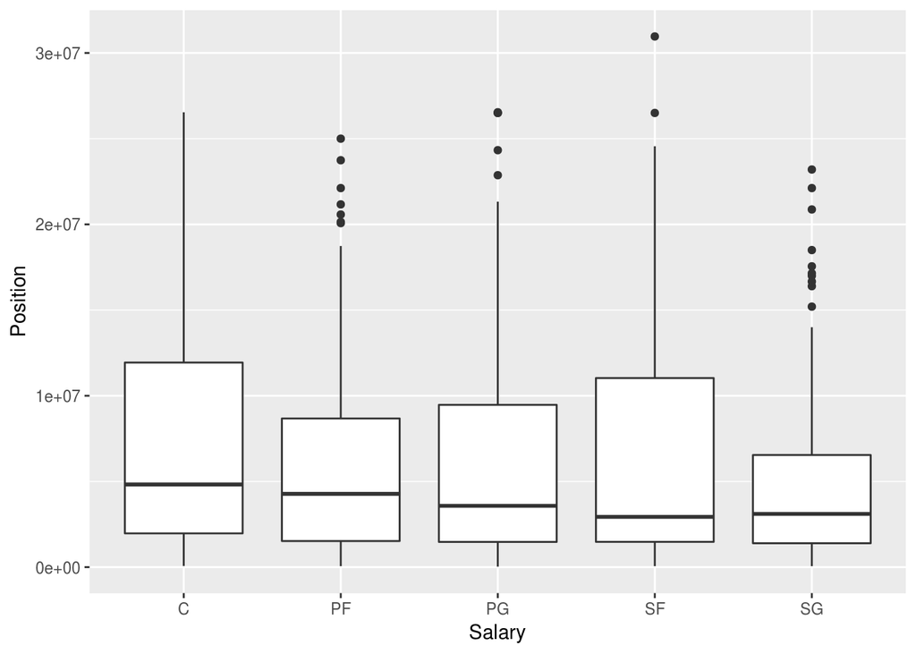

| Position | Avg_Salary |
| --- | --- |
| C | 4.82 |
| PF | 4.28 |
| PG | 3.58 |
| SF | 2.93 |
| SG | 3.11 |

### Salary EDA: Salary by Age

Below we observe a reasonable conclusion - better players get paid more and keep playing for longer. The highest density of players is between ages 25 and 30, around which pay seems to level off.

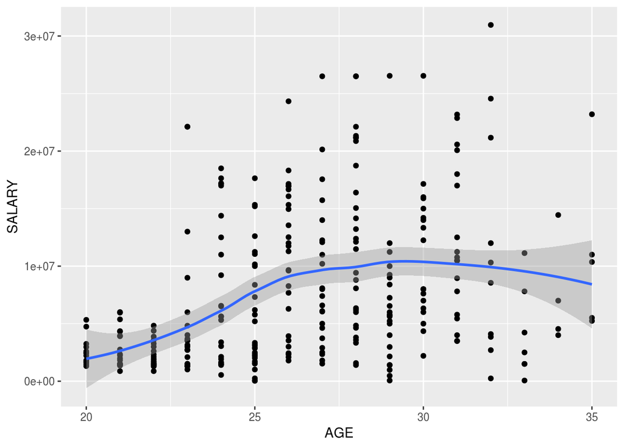

### Salary EDA: Player Rating by Salary

Another reasonable insight is displayed below - players who are rated higher have higher salaries.

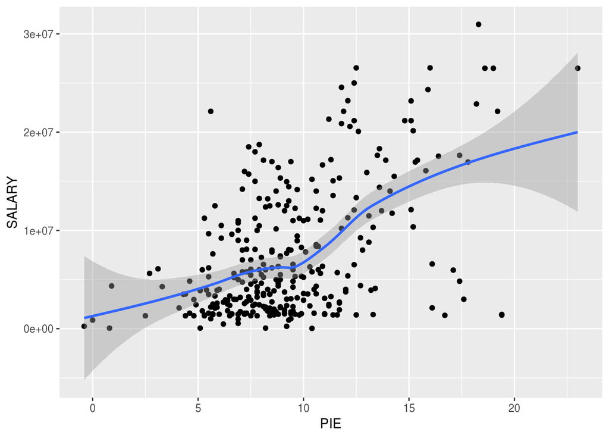

### Salary vs. Wikipedia Pageviews

Beginning with some social media statistics. There is a very weak positive correlation between salary and pageviews, with some clear outliers.

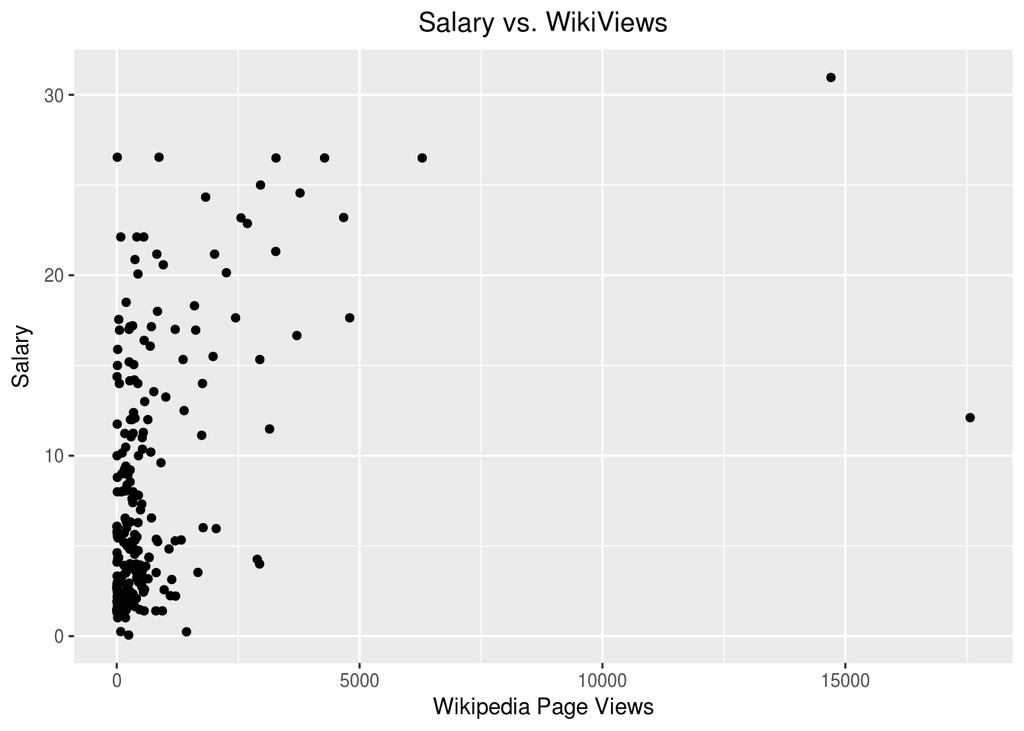

### Performance EDA: Points per game vs. significant other stats

After assessing a simple linear model and viewing which predictors were statistically significant to points per game, below we examine a graph of points per game versus 3P, 2P, FG, and FT. We see that less 3’s are made overall and a lot of collinearity exists which may cause problems later. Note: points per game is the player’s average number of total points per game, whereas these features represent the quantity of those shots made (e.g. total three point shots made).

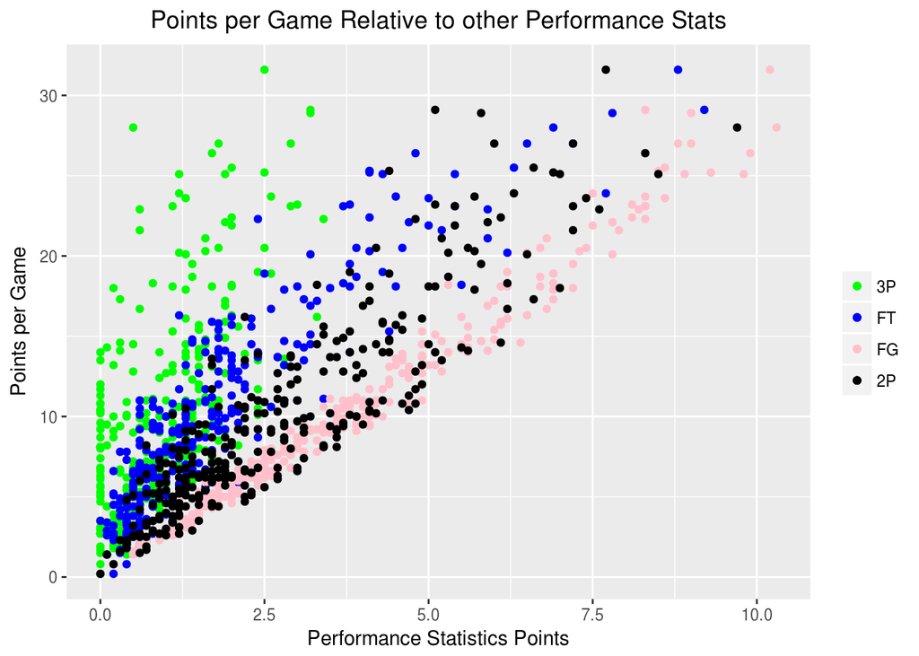

# Question 1: Can we predict **salary** from performance statistics?

Before answering the above question, what predictors will be used in the model? The first attempt used all predictors, leading to issues with collinearity. Then, 18 predictors were eliminated based on our domain knownledge. That still left nearly 20 predictors, far too many given the number of observation, so next best subset selection was used. Below are summary graphs for best subset elimination:

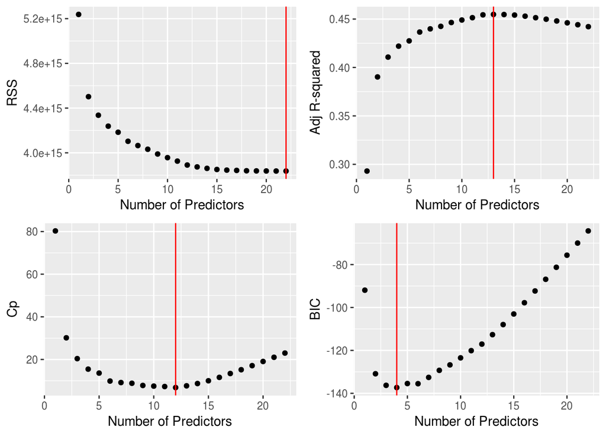

#### Predictors used by model

| NumberOfPredictors | Predictors |
| --- | --- |
| 4 | Age, 2PA, MPG, W |
| 5 | Age, 2PA, MPG, W, 2P |
| 6 | Age, 2PA, W, 2P, ORB, POINTS |
| 7 | Age, 2PA, W, 2P, ORB, POINTS, TOV |
| 8 | Age, 2PA, W, 2P, ORB, POINTS, TOV, STL |
| 9 | Age, W, 2P, ORB, POINTS, TOV, MPG, 3PA, FGA |
| 10 | Age, W, 2P, ORB, POINTS, TOV, MPG, 3PA, FGA, 2PA |
| 5 (Gamma) | Age, 2PA, 2P, 2PA, ORB, MPG |

#### Actual vs. Predicted Plots

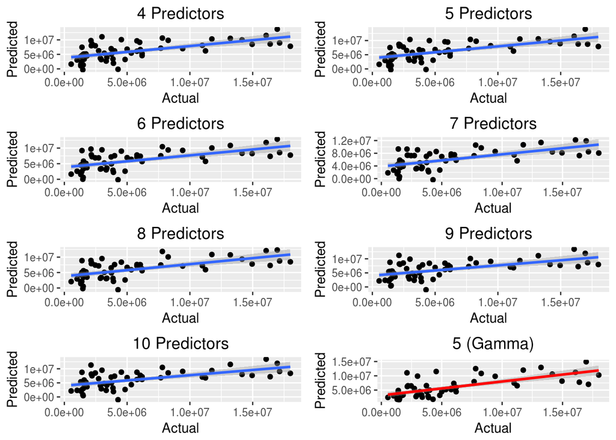

#### Test MSE by model

| Model4 | Model5 | Model6 | Model7 | Model8 | Model9 | Model10 | Gamma |
| --- | --- | --- | --- | --- | --- | --- | --- |
| 3832685 | 3756482 | 3865158 | 3847886 | 3846537 | 4017339 | 3974128 | 7449334 |

In addition to validation set, an attempt at k-fold cross validation was also performed. Below is the test MSE per model using cross validation, with $k=5$ folds. This also did not show much sucess - actually a slight increase in overall test MSE was observed.

#### K-fold Test MSE

| Model4 | Model5 | Model6 | Model7 | Model8 | Model9 | Model10 | Gamma |
| --- | --- | --- | --- | --- | --- | --- | --- |
| 3864109 | 3843969 | 3834071 | 3857219 | 3873927 | 3840637 | 3846813 | 8020020 |

Thus, our results with a linear model are not very conclusive. However, perhaps a non-linear model would work better. Hence, below are plots of variables (determined by best subset selection) against salary. We had hoped to see patters within the data, but this was not the case. In addition, two local regression models using 3 and 4 predictors were performed. Due to the small number of observations, we chose to keep the number of predictors very small. While the model looks acceptable, there is no significant increase or decrease in Test MSE. Overall, all models are inconclusive. That is, they are not horrible, but not nearly good enough to ensure a good prediction of salary.

#### Data patterns - would non-linear be good?

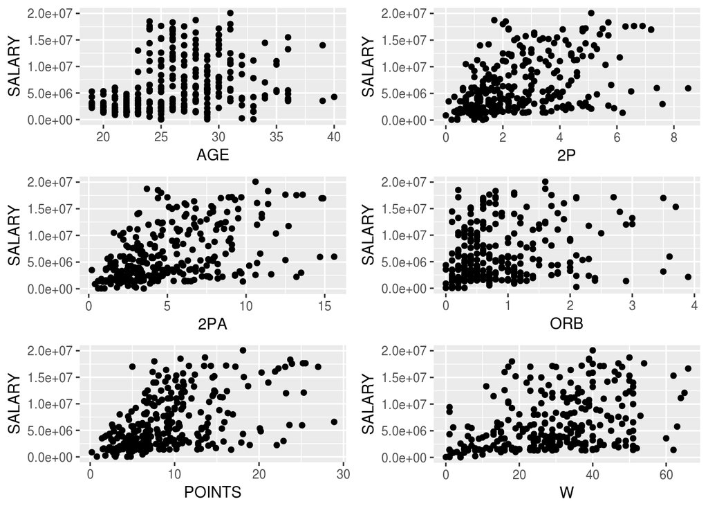

#### Actual vs. Predicted results using a non-linear model

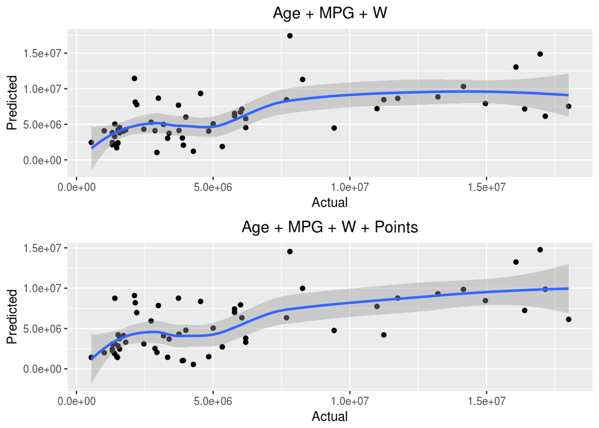

#### Test MSE using two nonlinear models

| NonLinear_3P | NonLinear_4P |
| --- | --- |
| 3989495 | 3833928 |

# Question 2: Predicting **Points per game** based on other performance metrics?

To begin, a simple linear model was performed to view predictors standing out as statistically significant. Suprisingly, only 4 predictors stood out: 3P, FT, FG, and 2P. However, these predictors are almost too correlated (as will be shown below). Additionally, best subset selection as used to determine the predictors to use, but the results were not consistent due to collinearity. Some results (see graphs in `Question2.R`) showed that we should use 3-4 statistics which we were already using (3P, FT, FG, 2P as stated above). Thus, we chose to first move forward with a linear regression to predict points per game using these predictors. To create training and testing data, a validation set approach as used with a 0.75/0.25 random split. Below we see the actual vs. predicted points for this model.

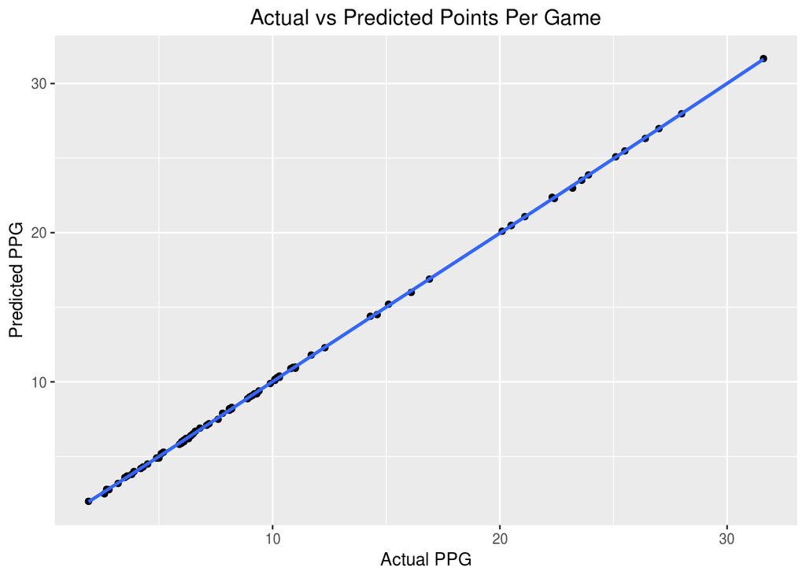

Reviewing the above shows a nearly perfect line which is a little suspicious. The RMSE is only 0.075. Are the “Points” simply the sum of our predictors (-FG) multiplied by their point values? While close, they are not the sum. This is still unsettling, and probably means that this model isn’t very useful overall.

| original_points | pred_points | sum_col |
| --- | --- | --- |
| 31.6 | 31.670 | 31.7 |
| 28.0 | 27.972 | 27.8 |
| 27.0 | 26.978 | 27.0 |
| 26.4 | 26.316 | 26.5 |
| 25.5 | 25.480 | 25.5 |
| 25.1 | 25.087 | 25.1 |
| 23.9 | 23.872 | 23.9 |
| 23.6 | 23.512 | 23.7 |
| 23.2 | 22.987 | 23.0 |
| 22.4 | 22.291 | 22.3 |

### Points per game based on FG alone?

Since adding these 4 predictors together seems like an obvious way to predict points per game, can we ask the model to learn how to predict points per game based on field goals alone? This question is interesting in that the make-up of shots that a person can have to generate the same number of points can vary so much, so the model would actually be learning something significant here. Below the actual vs. predicted points per game based on field goals is shown. This model looks great, and isn’t quite perfect (which is desirable). The RMSE is now 1.15.

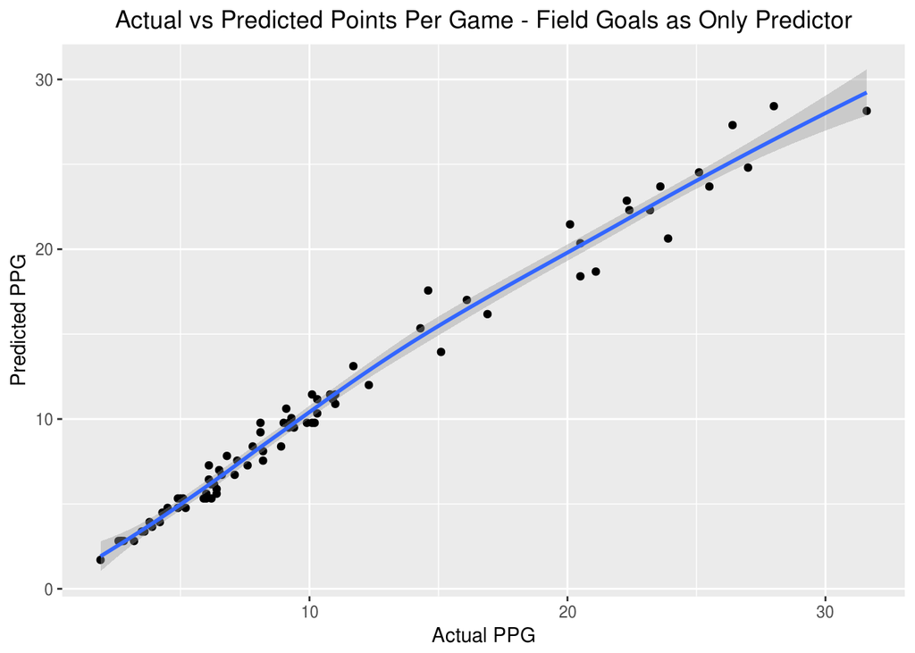

# Question 3: **Salary** based on social media stats?

For this question, can salary be predicted based on an individual’s Wikipedia pageviews, personal Twitter retweets, and personal Twitter favorites? Intuitively, players with a higher salary have more pageviews (since they’re more famous), but it has already been seen (in the EDA) that this correlation is weak. Additionally, we know Twitter predictions will be random - just because a player is more famous or has a higher salary doesn’t necessarily mean they have more twitter activity. Data was also not available on every individual’s endorsers/sponsors, which could cause some players to have more twitter activity.

The validation set approach is again used with a random 0.75/0.25 train/test split. Since there are only 3 predictors, we first create a model using only Wikipedia pageviews, before one using both Twitter stats combined and then finally a model using all three predictors.

#### Actual vs. Predicted Salaries (top is data against original, bottom is actual vs. predicted points)

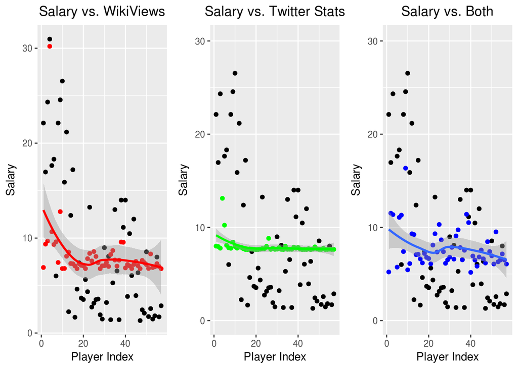

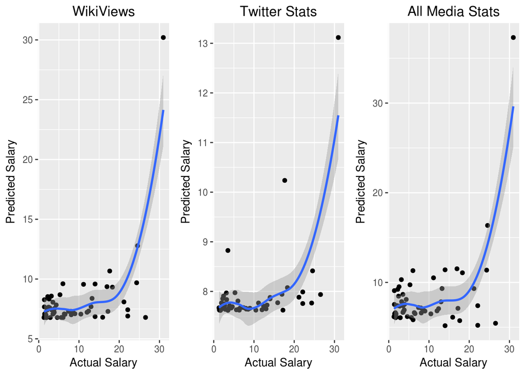

#### Compare Test RMSE of each model:

(Note: RMSE is scaled in millions (i.e. 6.7 million))

| wiki_rmse | twitter_rmse | media_rmse |
| --- | --- | --- |
| 6.721826 | 7.379934 | 6.860595 |

# Conclusion and Future Steps

Above, we examined three questions using the NBA Social Power dataset. While the models in questions 1 and 3 were not extremely sucessful, we learned more about predictor choice and the curse of dimensionality, as well as which statistics (performance and social media) which may affect a player’s salary the most. Question 2 taught us to beware of problems with collinearity, but we were able to craft nearly perfect model of a player’s points per game based on other performance metrics.

Further thoughts that we had and discussed in class regarding the salary vs. social media exploration were the difficult to evaluate salary based on social media without other factors including team and individual sponsorships and endorsements, among others. It would be interesting to explore this question further with that data. Additionally, since personal Twitter metrics are somewhat arbitrary, we would be interested in examining salary or player rating (PIE) vs. a player’s twitter mentions or tags instead, which we would expect to correlate more. We would also be interested in exploring Question 2 further, using atypical predictors to predict points per game and diving deeper into subset selection. We could also definitely run a K-fold cross validation, as we did in Question 1, to observe how different numbers of predictors affected model performance.